# Alevin-Fry Comparison of Resolution Modes

Ally Hawkins for CCDL

In this notebook we are comparing the use of the `cr-like` resolution in alevin-fry to the `cr-like-em` resolution. Previously in our benchmarking analysis we made the decision to use alevin-fry with the `splici` index and selective alignment (`salign`) for all samples, single-nucleus and single-cell. The one remaining question was about resolution. Alevin-fry using the `splici` index is recommended to be used in USA mode which is compatible with both `cr-like` and `cr-like-em`, so we have chosen to use one of these two methods. The difference between `cr-like` and `cr-like-em` is that the `cr-like-em` will use an expectation maximization algorithm to resolve multi-mapped reads, while `cr-like` will discard those reads.

Data in this notebook have been analyzed using alevin-fry 0.4.0 and salmon 1.5.1.

Here I am looking at comparisons of per cell QC metrics.

## Setup

```r
library(magrittr)
library(ggplot2)
library(SingleCellExperiment)
```

```r
# path to results files with sces and qc dataframes from running benchrmarking_generate_qc_df.R
base_dir <- here::here()
file_dir <- file.path(base_dir, "data", "cr-like-test", "results")

# qc files
quant_info_file <- file.path(file_dir, "quant_info.tsv")
coldata_df_file <- file.path(file_dir, "coldata_qc.tsv")
rowdata_df_file <- file.path(file_dir, "rowdata_qc.tsv")

# sce objects
cr_like_file <- file.path(file_dir, "splici_salign_cr-like_sces.rds")
cr_like_em_file <- file.path(file_dir, "splici_salign_cr-like-em_sces.rds")
cellranger_file <- file.path(file_dir, "cellranger_sces.rds")
```

```r
# read in dataframes needed for plotting
quant_info <- readr::read_tsv(quant_info_file)
coldata_df <- readr::read_tsv(coldata_df_file)
rowdata_df <- readr::read_tsv(rowdata_df_file)
```

```r
# read in sces
cr_like_sce <- readr::read_rds(cr_like_file)
cr_like_em_sce <- readr::read_rds(cr_like_em_file)
cellranger_sce <- readr::read_rds(cellranger_file)
```

```r
alevin_fry_tools <- c("splici_salign_cr-like", "splici_salign_cr-like-em")

# merge coldata df with quant_info
coldata_info_df <- coldata_df %>%
  # rename tool to be either cellranger or alevin-fry
  dplyr::mutate(tool = ifelse(tool %in% alevin_fry_tools, "alevin-fry", "cellranger")) %>%
  dplyr::left_join(quant_info,
                   by = c("tool" = "tool",
                          "quant_id" = "quant_dir")) %>%
  # rename the not_alevin to cellranger for plotting purposes
  dplyr::mutate(alevin_resolution = ifelse(alevin_resolution == "not_alevin", "cellranger", alevin_resolution))
```

```r
# split into cell and nucleus coldata
cell_coldata_qc <- coldata_info_df %>%
  dplyr::filter(seq_unit == "cell")

nucleus_coldata_qc <- coldata_info_df %>%
  dplyr::filter(seq_unit == "nucleus") %>%
  dplyr::filter(index_type == "splici")
```

## Per Cell QC Metrics

### All Cells

Let’s briefly look at the UMI/cell and genes detected/cell when looking at all cells with these methods.

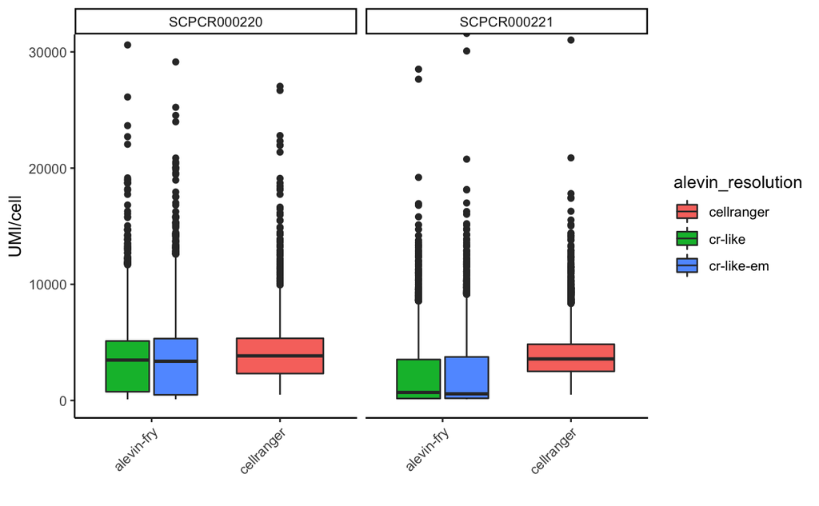

```r
ggplot(nucleus_coldata_qc, aes(x = tool, y = sum, fill = alevin_resolution)) +
  geom_boxplot() +
  facet_grid(~ sample) +
  theme_classic() +
  theme(axis.text.x = element_text(angle = 45, hjust = 1)) +
  ylab("UMI/cell") +
  xlab("") +
  coord_cartesian(ylim = c(0,30000))
```

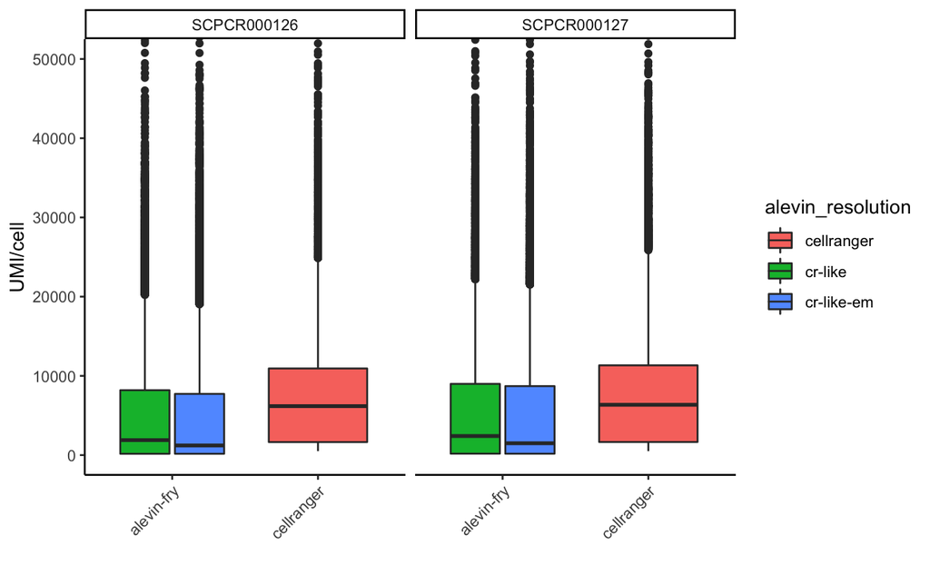

```r
ggplot(cell_coldata_qc, aes(x = tool, y = sum, fill = alevin_resolution)) +
  geom_boxplot() +
  facet_grid(~ sample) +
  theme_classic() +
  theme(axis.text.x = element_text(angle = 45, hjust = 1)) +
  ylab("UMI/cell") +
  xlab("") +
  coord_cartesian(ylim = c(0,50000))
```

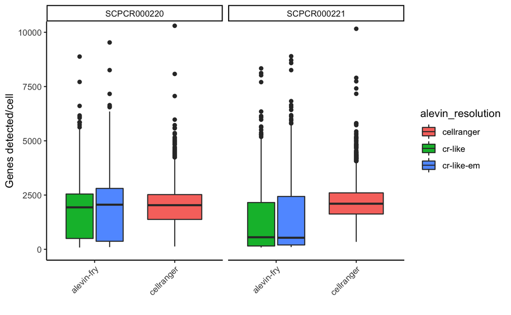

```r
ggplot(nucleus_coldata_qc, aes(x = tool, y = detected, fill = alevin_resolution)) +
  geom_boxplot() +
  facet_grid(~ sample) +
  theme_classic() +
  theme(axis.text.x = element_text(angle = 45, hjust = 1)) +
  ylab("Genes detected/cell") +
  xlab("") +
  coord_cartesian(ylim = c(0,10000))
```

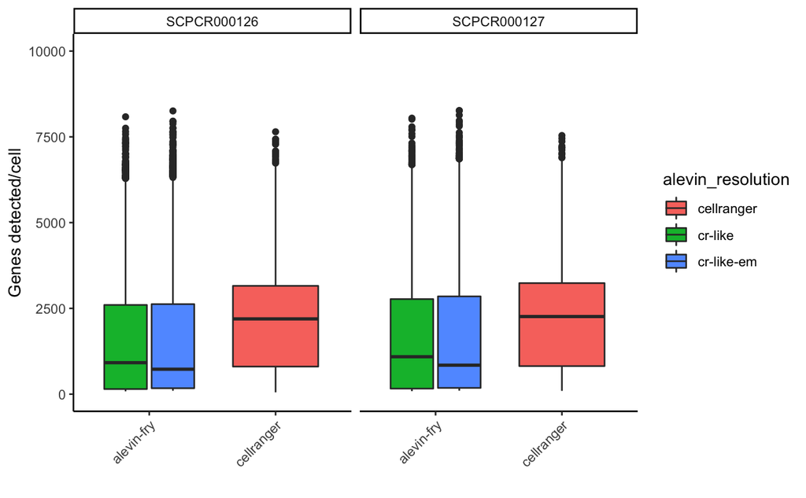

```r
ggplot(cell_coldata_qc, aes(x = tool, y = detected, fill = alevin_resolution)) +
  geom_boxplot() +
  facet_grid(~ sample) +
  theme_classic() +
  theme(axis.text.x = element_text(angle = 45, hjust = 1)) +
  ylab("Genes detected/cell") +
  xlab("") +
  coord_cartesian(ylim = c(0,10000))
```

As seen previously, when looking at all cells across all tools, we see that alevin-fry appears to detect lower UMI/cell and genes detected/cell than cellranger regardless of resolution. This is most likely due to the fact that alevin-fry detects more cells than cellranger and is an artifact of the filtering methods. There is a population of cells passing filtering in alevin-fry with lower UMI/cell and genes detected/cell that should probably be filtered out.

### Shared cells only

To be sure that is the case, let’s look at the shared cells only. Here we also want to compare the differences between the two resolution modes of alevin-fry.

```r
# filter for cells that are found in all configurations of alevin + cellranger
cell_counts <- cell_coldata_qc %>%
  dplyr::count(cell_id, sample)

common_cells <- cell_counts %>%
  dplyr::filter(n == 3) %>%
  dplyr::pull(cell_id)

cell_qc_common <- cell_coldata_qc %>%
  dplyr::filter(cell_id %in% common_cells)
```

```r
# filter for cells that are found in all configurations of alevin + cellranger
nuclei_counts <- nucleus_coldata_qc %>%
  dplyr::count(cell_id, sample)

common_nuclei <- nuclei_counts %>%
  dplyr::filter(n == 3) %>%
  dplyr::pull(cell_id)

nucleus_qc_common <- nucleus_coldata_qc %>%
  dplyr::filter(
    (cell_id %in% common_nuclei)
  )
```

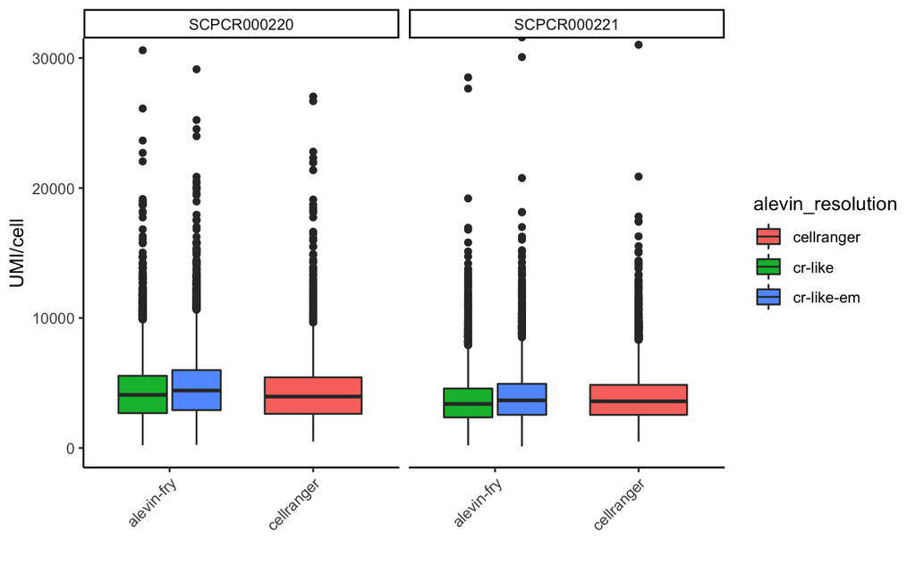

```r
ggplot(nucleus_qc_common, aes(x = tool, y = sum, fill = alevin_resolution)) +
  geom_boxplot() +
  facet_wrap(~ sample) +
  theme_classic() +
  theme(axis.text.x = element_text(angle = 45, hjust = 1)) +
  ylab("UMI/cell") +
  xlab("") +
  coord_cartesian(ylim = c(0,30000))
```

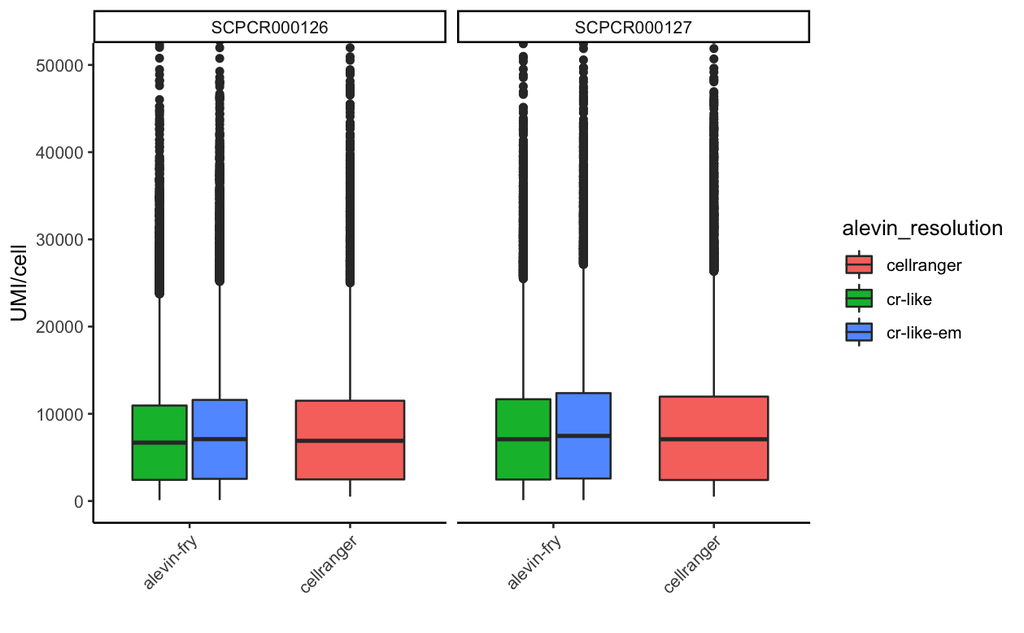

```r
ggplot(cell_qc_common, aes(x = tool, y = sum, fill = alevin_resolution)) +
  geom_boxplot() +
  facet_wrap(~ sample) +
  theme_classic() +
  theme(axis.text.x = element_text(angle = 45, hjust = 1)) +
  ylab("UMI/cell") +
  xlab("") +
  coord_cartesian(ylim = c(0,50000))
```

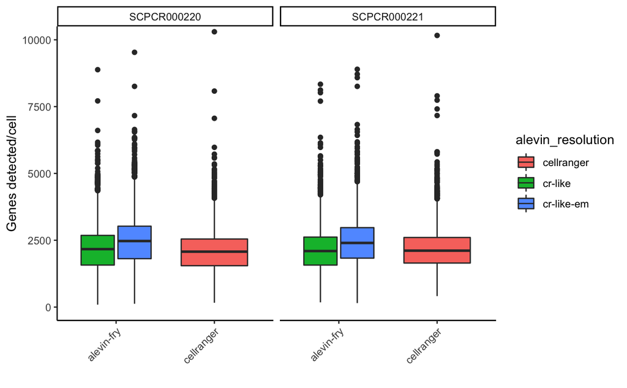

```r
ggplot(nucleus_qc_common, aes(x = tool, y = detected, fill = alevin_resolution)) +
  geom_boxplot() +
  facet_wrap(~ sample) +
  theme_classic() +
  theme(axis.text.x = element_text(angle = 45, hjust = 1)) +
  ylab("Genes detected/cell") +
  xlab("") +
  coord_cartesian(ylim = c(0,10000))
```

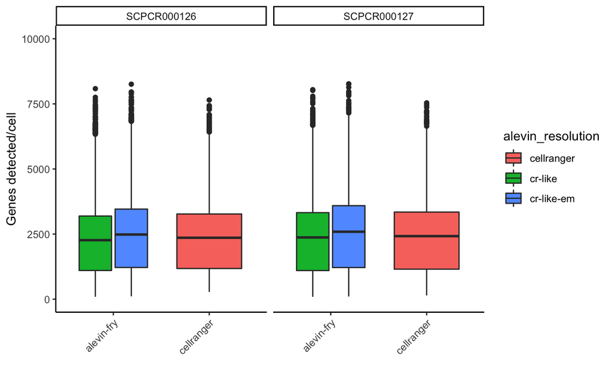

```r
ggplot(cell_qc_common, aes(x = tool, y = detected, fill = alevin_resolution)) +
  geom_boxplot() +
  facet_wrap(~ sample) +
  theme_classic() +
  theme(axis.text.x = element_text(angle = 45, hjust = 1)) +
  ylab("Genes detected/cell") +
  xlab("") +
  coord_cartesian(ylim = c(0,10000))
```

The `cr-like-em` resolution actually looks more similar to cellranger than the `cr-like` when looking at UMI/cell, but when looking at genes/cell you do see a shift upwards in the `cr-like-em`. Cellranger appears to be somewhere in the middle with overall no major differences between these resolutions and cellranger so I would be inclined to use `cr-like-em` to resolve multi-mapped reads.

### Gene overlap

Let’s look at if there is a difference in the actual genes that are detected overall between using `cr-like` and `cr-like-em` or if we are just picking up more genes/cell

```r
# make a function to filter sces by subset of cells and re-calculate feature stats
filter_sce <- function(sce, cells){
  cells_to_keep <- colnames(sce) %in% cells
  rowData(sce) <- NULL
  sce[, cells_to_keep] %>%
    scater::addPerFeatureQC()
}
```

```r
# split into cell and nucleus
resolution <- c('cr-like', 'cr-like-em')
cell_sces <- list(cr_like_sce[1:2],
                  cr_like_em_sce[1:2])
nucleus_sces <- list(cr_like_sce[3:4],
                     cr_like_em_sce[3:4])

names(cell_sces) <- resolution
names(nucleus_sces) <- resolution

# filter list of sces based on common cells
cell_sces_filtered <- cell_sces %>%
  purrr::map(
    ~ purrr::map(.x, filter_sce, cells = common_cells)
  )

nucleus_sces_filtered <- nucleus_sces %>%
  purrr::map(
    ~ purrr::map(.x, filter_sce, cells = common_nuclei)
  )

# grab rowdata and combine into dataframe to be used for plotting
cell_rowdata_filtered <- cell_sces %>%
  purrr::map_df(
    ~ purrr::map_df(.x, scpcaTools::rowdata_to_df, .id = "quant_dir"),
    .id = "alevin_resolution"
  )

nucleus_rowdata_filtered <- nucleus_sces %>%
  purrr::map_df(
    ~ purrr::map_df(.x, scpcaTools::rowdata_to_df, .id = "quant_dir"),
    .id = "alevin_resolution"
  )
# merge into one dataframe
all_rowdata_filtered <- rbind(cell_rowdata_filtered, nucleus_rowdata_filtered)

# join with quant info to get sample names
all_rowdata_filtered <- all_rowdata_filtered %>%
  dplyr::left_join(quant_info) %>%
  dplyr::filter(mean > 0 & detected > 0)
```

```r
# get list of cr_like and cr_like_em genes
cr_like_genes <- all_rowdata_filtered %>%
  dplyr::filter(alevin_resolution == "cr-like") %>%
  dplyr::pull(gene_id) %>%
  unique()

cr_like_em_genes <- all_rowdata_filtered %>%
  dplyr::filter(alevin_resolution == "cr-like-em") %>%
  dplyr::pull(gene_id) %>%
  unique()
```

```r
gene_overlap <- intersect(cr_like_genes, cr_like_em_genes)
glue::glue("Number of genes in cr-like {length(cr_like_genes)}")
```

```
Number of genes in cr-like 43943
```

```r
glue::glue("Number of genes in cr-like-em {length(cr_like_em_genes)}")
```

```
Number of genes in cr-like-em 45584
```

```r
glue::glue("Number of genes found in both {length(gene_overlap)}")
```

```
Number of genes found in both 43528
```

I’m going to look at gene expression and how this actually affects individual genes in another notebook.

|  | setting | value |
| --- | --- | --- |
| version | version | R version 4.0.5 (2021-03-31) |
| os | os | macOS Catalina 10.15.7 |
| system | system | x86_64, darwin17.0 |
| ui | ui | RStudio |
| language | language | (EN) |
| collate | collate | en_US.UTF-8 |
| ctype | ctype | en_US.UTF-8 |
| tz | tz | America/Chicago |
| date | date | 2021-07-28 |